# Risk Factor Analysis

## Outcome Variable

**Outcome Variable:** sstunted

## Predictor Variables

**Intervention Variable:** predexfd6

**Adjustment Set:**

- arm
- sex
- W_mage
- meducyrs
- feducyrs
- hhwealth_quart
- hfoodsec
- W_mhtcm
- vagbrth
- W_gagebrth
- W_birthwt
- W_birthlen
- W_nrooms
- W_nchldlt5
- month
- brthmon
- W_parity
- impfloor
- impsan
- safeh20
- delta_W_mage
- delta_meducyrs
- delta_feducyrs
- delta_hhwealth_quart
- delta_hfoodsec
- delta_W_mhtcm
- delta_vagbrth
- delta_W_gagebrth
- delta_W_birthwt
- delta_W_birthlen
- delta_W_nrooms
- delta_W_nchldlt5
- delta_month
- delta_brthmon
- delta_W_parity
- delta_impfloor
- delta_impsan
- delta_safeh20

## Stratifying Variables

The analysis was stratified on these variable(s):

- agecat
- studyid
- country

## Data Summary

| agecat | studyid | country | predexfd6 | sstunted | n_cell | n |
| --- | --- | --- | --- | --- | --- | --- |
| Birth | ki0047075b-MAL-ED | BANGLADESH | 1 | 0 | 117 | 231 |
| Birth | ki0047075b-MAL-ED | BANGLADESH | 1 | 1 | 2 | 231 |
| Birth | ki0047075b-MAL-ED | BANGLADESH | 0 | 0 | 108 | 231 |
| Birth | ki0047075b-MAL-ED | BANGLADESH | 0 | 1 | 4 | 231 |
| Birth | ki0047075b-MAL-ED | BRAZIL | 1 | 0 | 26 | 175 |
| Birth | ki0047075b-MAL-ED | BRAZIL | 1 | 1 | 1 | 175 |
| Birth | ki0047075b-MAL-ED | BRAZIL | 0 | 0 | 142 | 175 |
| Birth | ki0047075b-MAL-ED | BRAZIL | 0 | 1 | 6 | 175 |
| Birth | ki0047075b-MAL-ED | INDIA | 1 | 0 | 13 | 190 |
| Birth | ki0047075b-MAL-ED | INDIA | 1 | 1 | 2 | 190 |
| Birth | ki0047075b-MAL-ED | INDIA | 0 | 0 | 170 | 190 |
| Birth | ki0047075b-MAL-ED | INDIA | 0 | 1 | 5 | 190 |
| Birth | ki0047075b-MAL-ED | NEPAL | 1 | 0 | 22 | 170 |
| Birth | ki0047075b-MAL-ED | NEPAL | 1 | 1 | 1 | 170 |
| Birth | ki0047075b-MAL-ED | NEPAL | 0 | 0 | 142 | 170 |
| Birth | ki0047075b-MAL-ED | NEPAL | 0 | 1 | 5 | 170 |
| Birth | ki0047075b-MAL-ED | PERU | 1 | 0 | 104 | 256 |
| Birth | ki0047075b-MAL-ED | PERU | 1 | 1 | 2 | 256 |
| Birth | ki0047075b-MAL-ED | PERU | 0 | 0 | 146 | 256 |
| Birth | ki0047075b-MAL-ED | PERU | 0 | 1 | 4 | 256 |
| Birth | ki0047075b-MAL-ED | SOUTH AFRICA | 1 | 0 | 3 | 211 |
| Birth | ki0047075b-MAL-ED | SOUTH AFRICA | 1 | 1 | 0 | 211 |
| Birth | ki0047075b-MAL-ED | SOUTH AFRICA | 0 | 0 | 207 | 211 |
| Birth | ki0047075b-MAL-ED | SOUTH AFRICA | 0 | 1 | 1 | 211 |
| Birth | ki0047075b-MAL-ED | TANZANIA, UNITED REPUBLIC OF | 1 | 0 | 1 | 119 |
| Birth | ki0047075b-MAL-ED | TANZANIA, UNITED REPUBLIC OF | 1 | 1 | 0 | 119 |
| Birth | ki0047075b-MAL-ED | TANZANIA, UNITED REPUBLIC OF | 0 | 0 | 113 | 119 |
| Birth | ki0047075b-MAL-ED | TANZANIA, UNITED REPUBLIC OF | 0 | 1 | 5 | 119 |
| Birth | ki1000108-CMC-V-BCS-2002 | INDIA | 1 | 0 | 7 | 7 |
| Birth | ki1000108-CMC-V-BCS-2002 | INDIA | 1 | 1 | 0 | 7 |

[output cut: 158 more lines]

The following strata were considered:

- agecat: 24 months, studyid: ki0047075b-MAL-ED, country: BANGLADESH
- agecat: 24 months, studyid: ki0047075b-MAL-ED, country: BRAZIL
- agecat: 24 months, studyid: ki0047075b-MAL-ED, country: INDIA
- agecat: 24 months, studyid: ki0047075b-MAL-ED, country: NEPAL
- agecat: 24 months, studyid: ki0047075b-MAL-ED, country: PERU
- agecat: 24 months, studyid: ki0047075b-MAL-ED, country: SOUTH AFRICA
- agecat: 24 months, studyid: ki0047075b-MAL-ED, country: TANZANIA, UNITED REPUBLIC OF
- agecat: 24 months, studyid: ki1000108-CMC-V-BCS-2002, country: INDIA
- agecat: 24 months, studyid: ki1000108-IRC, country: INDIA
- agecat: 24 months, studyid: ki1017093b-PROVIDE, country: BANGLADESH
- agecat: 24 months, studyid: ki1101329-Keneba, country: GAMBIA
- agecat: 24 months, studyid: ki1113344-GMS-Nepal, country: NEPAL
- agecat: 24 months, studyid: ki1148112-LCNI-5, country: MALAWI
- agecat: 24 months, studyid: kiGH5241-JiVitA-3, country: BANGLADESH
- agecat: 24 months, studyid: kiGH5241-JiVitA-4, country: BANGLADESH
- agecat: 6 months, studyid: ki0047075b-MAL-ED, country: BANGLADESH
- agecat: 6 months, studyid: ki0047075b-MAL-ED, country: BRAZIL
- agecat: 6 months, studyid: ki0047075b-MAL-ED, country: INDIA
- agecat: 6 months, studyid: ki0047075b-MAL-ED, country: NEPAL
- agecat: 6 months, studyid: ki0047075b-MAL-ED, country: PERU
- agecat: 6 months, studyid: ki0047075b-MAL-ED, country: SOUTH AFRICA
- agecat: 6 months, studyid: ki0047075b-MAL-ED, country: TANZANIA, UNITED REPUBLIC OF
- agecat: 6 months, studyid: ki1000108-CMC-V-BCS-2002, country: INDIA
- agecat: 6 months, studyid: ki1000108-IRC, country: INDIA
- agecat: 6 months, studyid: ki1000109-EE, country: PAKISTAN
- agecat: 6 months, studyid: ki1000304b-SAS-CompFeed, country: INDIA
- agecat: 6 months, studyid: ki1000304b-SAS-FoodSuppl, country: INDIA
- agecat: 6 months, studyid: ki1017093b-PROVIDE, country: BANGLADESH
- agecat: 6 months, studyid: ki1101329-Keneba, country: GAMBIA
- agecat: 6 months, studyid: ki1113344-GMS-Nepal, country: NEPAL
- agecat: 6 months, studyid: ki1148112-LCNI-5, country: MALAWI
- agecat: 6 months, studyid: kiGH5241-JiVitA-3, country: BANGLADESH
- agecat: 6 months, studyid: kiGH5241-JiVitA-4, country: BANGLADESH
- agecat: Birth, studyid: ki0047075b-MAL-ED, country: BANGLADESH
- agecat: Birth, studyid: ki0047075b-MAL-ED, country: BRAZIL
- agecat: Birth, studyid: ki0047075b-MAL-ED, country: INDIA
- agecat: Birth, studyid: ki0047075b-MAL-ED, country: NEPAL
- agecat: Birth, studyid: ki0047075b-MAL-ED, country: PERU
- agecat: Birth, studyid: ki0047075b-MAL-ED, country: SOUTH AFRICA
- agecat: Birth, studyid: ki0047075b-MAL-ED, country: TANZANIA, UNITED REPUBLIC OF
- agecat: Birth, studyid: ki1000108-CMC-V-BCS-2002, country: INDIA
- agecat: Birth, studyid: ki1000108-IRC, country: INDIA
- agecat: Birth, studyid: ki1000109-EE, country: PAKISTAN
- agecat: Birth, studyid: ki1000304b-SAS-CompFeed, country: INDIA
- agecat: Birth, studyid: ki1101329-Keneba, country: GAMBIA
- agecat: Birth, studyid: kiGH5241-JiVitA-3, country: BANGLADESH
- agecat: Birth, studyid: kiGH5241-JiVitA-4, country: BANGLADESH

### Dropped Strata

Some strata were dropped due to rare outcomes:

- agecat: Birth, studyid: ki0047075b-MAL-ED, country: BANGLADESH
- agecat: Birth, studyid: ki0047075b-MAL-ED, country: BRAZIL
- agecat: Birth, studyid: ki0047075b-MAL-ED, country: INDIA
- agecat: Birth, studyid: ki0047075b-MAL-ED, country: NEPAL
- agecat: Birth, studyid: ki0047075b-MAL-ED, country: PERU
- agecat: Birth, studyid: ki0047075b-MAL-ED, country: SOUTH AFRICA
- agecat: Birth, studyid: ki0047075b-MAL-ED, country: TANZANIA, UNITED REPUBLIC OF
- agecat: Birth, studyid: ki1000108-CMC-V-BCS-2002, country: INDIA
- agecat: Birth, studyid: ki1000108-IRC, country: INDIA
- agecat: Birth, studyid: ki1000109-EE, country: PAKISTAN
- agecat: Birth, studyid: ki1000304b-SAS-CompFeed, country: INDIA
- agecat: 6 months, studyid: ki0047075b-MAL-ED, country: BANGLADESH
- agecat: 6 months, studyid: ki0047075b-MAL-ED, country: BRAZIL
- agecat: 6 months, studyid: ki0047075b-MAL-ED, country: INDIA
- agecat: 6 months, studyid: ki0047075b-MAL-ED, country: NEPAL
- agecat: 6 months, studyid: ki0047075b-MAL-ED, country: PERU
- agecat: 6 months, studyid: ki0047075b-MAL-ED, country: SOUTH AFRICA
- agecat: 6 months, studyid: ki0047075b-MAL-ED, country: TANZANIA, UNITED REPUBLIC OF
- agecat: 6 months, studyid: ki1000108-CMC-V-BCS-2002, country: INDIA
- agecat: 6 months, studyid: ki1000108-IRC, country: INDIA
- agecat: 6 months, studyid: ki1000304b-SAS-CompFeed, country: INDIA
- agecat: 6 months, studyid: ki1000304b-SAS-FoodSuppl, country: INDIA
- agecat: 6 months, studyid: ki1017093b-PROVIDE, country: BANGLADESH
- agecat: 6 months, studyid: ki1148112-LCNI-5, country: MALAWI
- agecat: 24 months, studyid: ki0047075b-MAL-ED, country: BRAZIL
- agecat: 24 months, studyid: ki0047075b-MAL-ED, country: INDIA
- agecat: 24 months, studyid: ki0047075b-MAL-ED, country: NEPAL
- agecat: 24 months, studyid: ki0047075b-MAL-ED, country: PERU
- agecat: 24 months, studyid: ki0047075b-MAL-ED, country: SOUTH AFRICA
- agecat: 24 months, studyid: ki0047075b-MAL-ED, country: TANZANIA, UNITED REPUBLIC OF
- agecat: 24 months, studyid: ki1000108-CMC-V-BCS-2002, country: INDIA
- agecat: 24 months, studyid: ki1000108-IRC, country: INDIA
- agecat: 24 months, studyid: ki1148112-LCNI-5, country: MALAWI

## Methods Detail

We’re interested in the causal parameters $E[Y_a]$ for all values of $a \in \mathcal{A}$. These parameters represent the mean outcome if, possibly contrary to fact, we intervened to set all units to have $A=a$. Under the randomization and positivity assumptions, these are identified by the statistical parameters $\psi_a=E_W[E_{Y|A,W}(Y|A=a,W)]$. In addition, we’re interested in the mean of $Y$, $E[Y]$ under no intervention (the observed mean). We will estimate these parameters by using SuperLearner to fit the relevant likelihood factors – $E_{Y|A,W}(Y|A=a,W)$ and $p(A=a|W)$, and then updating our likelihood fit using a joint TMLE.

For unadjusted analyses ($W=\{\}$), initial likelihoods were estimated using Lrnr_glm to estimate the simple $E(Y|A)$ and Lrnr_mean to estimate $p(A)$. For adjusted analyses, a small library containing Lrnr_glmnet, Lrnr_xgboost, and Lrnr_mean was used.

Having estimated these parameters, we will then use the delta method to estimate relative risks and attributable risks relative to a prespecified baseline level of $A$.

# Results Detail

## Results Plots

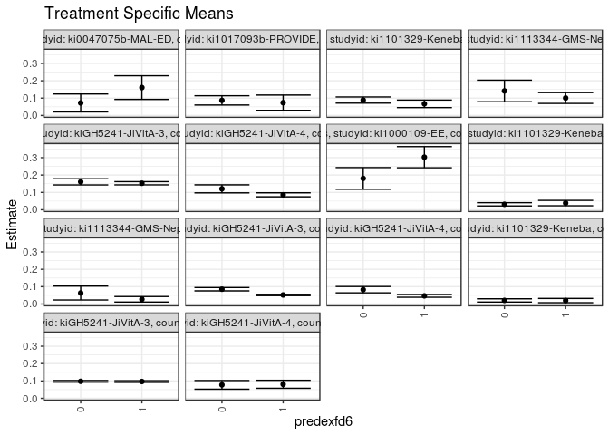

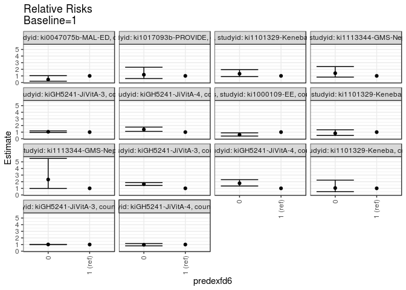

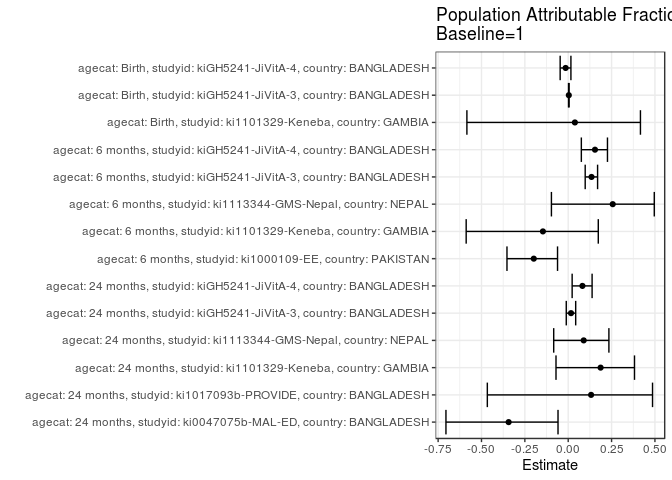

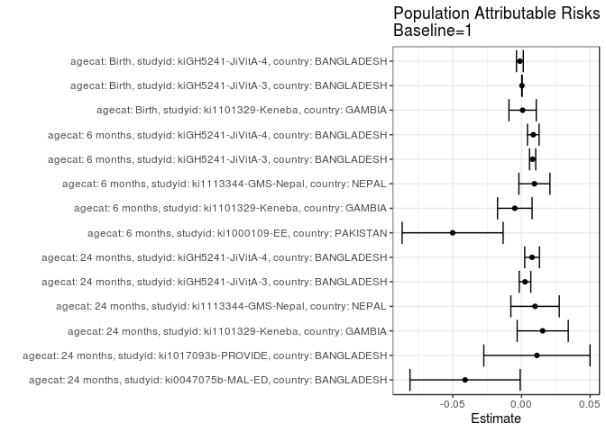

## Results Table

### Parameter: TSM

| agecat | studyid | country | intervention_level | baseline_level | estimate | ci_lower | ci_upper |
| --- | --- | --- | --- | --- | --- | --- | --- |
| Birth | ki1101329-Keneba | GAMBIA | 1 | NA | 0.0199018 | 0.0076673 | 0.0321362 |
| Birth | ki1101329-Keneba | GAMBIA | 0 | NA | 0.0207798 | 0.0114877 | 0.0300719 |
| Birth | kiGH5241-JiVitA-3 | BANGLADESH | 1 | NA | 0.0967214 | 0.0921753 | 0.1012674 |
| Birth | kiGH5241-JiVitA-3 | BANGLADESH | 0 | NA | 0.0978247 | 0.0931830 | 0.1024663 |
| Birth | kiGH5241-JiVitA-4 | BANGLADESH | 1 | NA | 0.0807210 | 0.0577295 | 0.1037125 |
| Birth | kiGH5241-JiVitA-4 | BANGLADESH | 0 | NA | 0.0774676 | 0.0524508 | 0.1024845 |
| 6 months | ki1000109-EE | PAKISTAN | 1 | NA | 0.3028463 | 0.2419492 | 0.3637435 |
| 6 months | ki1000109-EE | PAKISTAN | 0 | NA | 0.1805197 | 0.1181085 | 0.2429309 |
| 6 months | ki1101329-Keneba | GAMBIA | 1 | NA | 0.0384343 | 0.0229542 | 0.0539145 |
| 6 months | ki1101329-Keneba | GAMBIA | 0 | NA | 0.0314253 | 0.0219930 | 0.0408575 |
| 6 months | ki1113344-GMS-Nepal | NEPAL | 1 | NA | 0.0272277 | 0.0113435 | 0.0431120 |
| 6 months | ki1113344-GMS-Nepal | NEPAL | 0 | NA | 0.0633803 | 0.0232695 | 0.1034910 |
| 6 months | kiGH5241-JiVitA-3 | BANGLADESH | 1 | NA | 0.0520966 | 0.0482481 | 0.0559451 |
| 6 months | kiGH5241-JiVitA-3 | BANGLADESH | 0 | NA | 0.0852033 | 0.0755968 | 0.0948099 |
| 6 months | kiGH5241-JiVitA-4 | BANGLADESH | 1 | NA | 0.0468583 | 0.0388276 | 0.0548889 |
| 6 months | kiGH5241-JiVitA-4 | BANGLADESH | 0 | NA | 0.0825668 | 0.0643129 | 0.1008207 |
| 24 months | ki0047075b-MAL-ED | BANGLADESH | 1 | NA | 0.1607143 | 0.0925334 | 0.2288952 |
| 24 months | ki0047075b-MAL-ED | BANGLADESH | 0 | NA | 0.0721649 | 0.0205468 | 0.1237831 |
| 24 months | ki1017093b-PROVIDE | BANGLADESH | 1 | NA | 0.0737120 | 0.0297847 | 0.1176392 |
| 24 months | ki1017093b-PROVIDE | BANGLADESH | 0 | NA | 0.0869479 | 0.0602636 | 0.1136323 |
| 24 months | ki1101329-Keneba | GAMBIA | 1 | NA | 0.0671837 | 0.0453838 | 0.0889837 |
| 24 months | ki1101329-Keneba | GAMBIA | 0 | NA | 0.0889012 | 0.0711198 | 0.1066826 |
| 24 months | ki1113344-GMS-Nepal | NEPAL | 1 | NA | 0.1005608 | 0.0694109 | 0.1317108 |
| 24 months | ki1113344-GMS-Nepal | NEPAL | 0 | NA | 0.1412620 | 0.0790672 | 0.2034567 |
| 24 months | kiGH5241-JiVitA-3 | BANGLADESH | 1 | NA | 0.1525852 | 0.1433206 | 0.1618499 |
| 24 months | kiGH5241-JiVitA-3 | BANGLADESH | 0 | NA | 0.1606992 | 0.1429735 | 0.1784248 |
| 24 months | kiGH5241-JiVitA-4 | BANGLADESH | 1 | NA | 0.0862146 | 0.0747433 | 0.0976858 |
| 24 months | kiGH5241-JiVitA-4 | BANGLADESH | 0 | NA | 0.1204978 | 0.0973642 | 0.1436314 |

### Parameter: E(Y)

| agecat | studyid | country | intervention_level | baseline_level | estimate | ci_lower | ci_upper |
| --- | --- | --- | --- | --- | --- | --- | --- |
| Birth | ki1101329-Keneba | GAMBIA | NA | NA | 0.0206995 | 0.0132415 | 0.0281575 |
| Birth | kiGH5241-JiVitA-3 | BANGLADESH | NA | NA | 0.0970548 | 0.0924831 | 0.1016266 |
| Birth | kiGH5241-JiVitA-4 | BANGLADESH | NA | NA | 0.0795306 | 0.0569401 | 0.1021211 |
| 6 months | ki1000109-EE | PAKISTAN | NA | NA | 0.2526882 | 0.2084696 | 0.2969067 |
| 6 months | ki1101329-Keneba | GAMBIA | NA | NA | 0.0335430 | 0.0254620 | 0.0416240 |
| 6 months | ki1113344-GMS-Nepal | NEPAL | NA | NA | 0.0366300 | 0.0208588 | 0.0524012 |
| 6 months | kiGH5241-JiVitA-3 | BANGLADESH | NA | NA | 0.0601846 | 0.0563303 | 0.0640390 |
| 6 months | kiGH5241-JiVitA-4 | BANGLADESH | NA | NA | 0.0554121 | 0.0477101 | 0.0631140 |
| 24 months | ki0047075b-MAL-ED | BANGLADESH | NA | NA | 0.1196172 | 0.0755162 | 0.1637183 |
| 24 months | ki1017093b-PROVIDE | BANGLADESH | NA | NA | 0.0849220 | 0.0621566 | 0.1076874 |
| 24 months | ki1101329-Keneba | GAMBIA | NA | NA | 0.0826173 | 0.0687407 | 0.0964939 |
| 24 months | ki1113344-GMS-Nepal | NEPAL | NA | NA | 0.1104167 | 0.0823500 | 0.1384833 |
| 24 months | kiGH5241-JiVitA-3 | BANGLADESH | NA | NA | 0.1551159 | 0.1463315 | 0.1639003 |
| 24 months | kiGH5241-JiVitA-4 | BANGLADESH | NA | NA | 0.0939147 | 0.0835386 | 0.1042909 |

### Parameter: RR

| agecat | studyid | country | intervention_level | baseline_level | estimate | ci_lower | ci_upper |
| --- | --- | --- | --- | --- | --- | --- | --- |
| Birth | ki1101329-Keneba | GAMBIA | 1 | 1 | 1.0000000 | 1.0000000 | 1.0000000 |
| Birth | ki1101329-Keneba | GAMBIA | 0 | 1 | 1.0441205 | 0.4881134 | 2.2334719 |
| Birth | kiGH5241-JiVitA-3 | BANGLADESH | 1 | 1 | 1.0000000 | 1.0000000 | 1.0000000 |
| Birth | kiGH5241-JiVitA-3 | BANGLADESH | 0 | 1 | 1.0114072 | 1.0058902 | 1.0169545 |
| Birth | kiGH5241-JiVitA-4 | BANGLADESH | 1 | 1 | 1.0000000 | 1.0000000 | 1.0000000 |
| Birth | kiGH5241-JiVitA-4 | BANGLADESH | 0 | 1 | 0.9596964 | 0.8030057 | 1.1469621 |
| 6 months | ki1000109-EE | PAKISTAN | 1 | 1 | 1.0000000 | 1.0000000 | 1.0000000 |
| 6 months | ki1000109-EE | PAKISTAN | 0 | 1 | 0.5960769 | 0.3999295 | 0.8884258 |
| 6 months | ki1101329-Keneba | GAMBIA | 1 | 1 | 1.0000000 | 1.0000000 | 1.0000000 |
| 6 months | ki1101329-Keneba | GAMBIA | 0 | 1 | 0.8176349 | 0.4950313 | 1.3504739 |
| 6 months | ki1113344-GMS-Nepal | NEPAL | 1 | 1 | 1.0000000 | 1.0000000 | 1.0000000 |
| 6 months | ki1113344-GMS-Nepal | NEPAL | 0 | 1 | 2.3277849 | 0.9843161 | 5.5049211 |
| 6 months | kiGH5241-JiVitA-3 | BANGLADESH | 1 | 1 | 1.0000000 | 1.0000000 | 1.0000000 |
| 6 months | kiGH5241-JiVitA-3 | BANGLADESH | 0 | 1 | 1.6354881 | 1.4404437 | 1.8569426 |
| 6 months | kiGH5241-JiVitA-4 | BANGLADESH | 1 | 1 | 1.0000000 | 1.0000000 | 1.0000000 |
| 6 months | kiGH5241-JiVitA-4 | BANGLADESH | 0 | 1 | 1.7620539 | 1.3498909 | 2.3000627 |
| 24 months | ki0047075b-MAL-ED | BANGLADESH | 1 | 1 | 1.0000000 | 1.0000000 | 1.0000000 |
| 24 months | ki0047075b-MAL-ED | BANGLADESH | 0 | 1 | 0.4490263 | 0.1954795 | 1.0314363 |
| 24 months | ki1017093b-PROVIDE | BANGLADESH | 1 | 1 | 1.0000000 | 1.0000000 | 1.0000000 |
| 24 months | ki1017093b-PROVIDE | BANGLADESH | 0 | 1 | 1.1795628 | 0.6032160 | 2.3065841 |
| 24 months | ki1101329-Keneba | GAMBIA | 1 | 1 | 1.0000000 | 1.0000000 | 1.0000000 |
| 24 months | ki1101329-Keneba | GAMBIA | 0 | 1 | 1.3232550 | 0.9039187 | 1.9371252 |
| 24 months | ki1113344-GMS-Nepal | NEPAL | 1 | 1 | 1.0000000 | 1.0000000 | 1.0000000 |
| 24 months | ki1113344-GMS-Nepal | NEPAL | 0 | 1 | 1.4047412 | 0.8197905 | 2.4070759 |
| 24 months | kiGH5241-JiVitA-3 | BANGLADESH | 1 | 1 | 1.0000000 | 1.0000000 | 1.0000000 |
| 24 months | kiGH5241-JiVitA-3 | BANGLADESH | 0 | 1 | 1.0531763 | 0.9375213 | 1.1830989 |
| 24 months | kiGH5241-JiVitA-4 | BANGLADESH | 1 | 1 | 1.0000000 | 1.0000000 | 1.0000000 |
| 24 months | kiGH5241-JiVitA-4 | BANGLADESH | 0 | 1 | 1.3976508 | 1.1128952 | 1.7552666 |

### Parameter: PAR

| agecat | studyid | country | intervention_level | baseline_level | estimate | ci_lower | ci_upper |
| --- | --- | --- | --- | --- | --- | --- | --- |
| Birth | ki1101329-Keneba | GAMBIA | 1 | NA | 0.0007978 | -0.0091457 | 0.0107412 |
| Birth | kiGH5241-JiVitA-3 | BANGLADESH | 1 | NA | 0.0003335 | 0.0001758 | 0.0004911 |
| Birth | kiGH5241-JiVitA-4 | BANGLADESH | 1 | NA | -0.0011903 | -0.0036704 | 0.0012897 |
| 6 months | ki1000109-EE | PAKISTAN | 1 | NA | -0.0501582 | -0.0869372 | -0.0133791 |
| 6 months | ki1101329-Keneba | GAMBIA | 1 | NA | -0.0048914 | -0.0174790 | 0.0076962 |
| 6 months | ki1113344-GMS-Nepal | NEPAL | 1 | NA | 0.0094023 | -0.0018963 | 0.0207010 |
| 6 months | kiGH5241-JiVitA-3 | BANGLADESH | 1 | NA | 0.0080880 | 0.0058438 | 0.0103323 |
| 6 months | kiGH5241-JiVitA-4 | BANGLADESH | 1 | NA | 0.0085538 | 0.0043191 | 0.0127885 |
| 24 months | ki0047075b-MAL-ED | BANGLADESH | 1 | NA | -0.0410971 | -0.0812377 | -0.0009564 |
| 24 months | ki1017093b-PROVIDE | BANGLADESH | 1 | NA | 0.0112100 | -0.0274686 | 0.0498886 |
| 24 months | ki1101329-Keneba | GAMBIA | 1 | NA | 0.0154336 | -0.0031683 | 0.0340355 |
| 24 months | ki1113344-GMS-Nepal | NEPAL | 1 | NA | 0.0098558 | -0.0077737 | 0.0274853 |
| 24 months | kiGH5241-JiVitA-3 | BANGLADESH | 1 | NA | 0.0025307 | -0.0016973 | 0.0067586 |
| 24 months | kiGH5241-JiVitA-4 | BANGLADESH | 1 | NA | 0.0077002 | 0.0023312 | 0.0130691 |

### Parameter: PAF

| agecat | studyid | country | intervention_level | baseline_level | estimate | ci_lower | ci_upper |
| --- | --- | --- | --- | --- | --- | --- | --- |
| Birth | ki1101329-Keneba | GAMBIA | 1 | NA | 0.0385396 | -0.5841732 | 0.4164741 |
| Birth | kiGH5241-JiVitA-3 | BANGLADESH | 1 | NA | 0.0034357 | 0.0018310 | 0.0050379 |
| Birth | kiGH5241-JiVitA-4 | BANGLADESH | 1 | NA | -0.0149671 | -0.0464586 | 0.0155767 |
| 6 months | ki1000109-EE | PAKISTAN | 1 | NA | -0.1984983 | -0.3531075 | -0.0615551 |
| 6 months | ki1101329-Keneba | GAMBIA | 1 | NA | -0.1458240 | -0.5883144 | 0.1733925 |
| 6 months | ki1113344-GMS-Nepal | NEPAL | 1 | NA | 0.2566832 | -0.0967984 | 0.4962429 |
| 6 months | kiGH5241-JiVitA-3 | BANGLADESH | 1 | NA | 0.1343873 | 0.0979192 | 0.1693811 |
| 6 months | kiGH5241-JiVitA-4 | BANGLADESH | 1 | NA | 0.1543669 | 0.0756920 | 0.2263452 |
| 24 months | ki0047075b-MAL-ED | BANGLADESH | 1 | NA | -0.3435714 | -0.7049407 | -0.0587959 |
| 24 months | ki1017093b-PROVIDE | BANGLADESH | 1 | NA | 0.1320039 | -0.4663569 | 0.4861979 |
| 24 months | ki1101329-Keneba | GAMBIA | 1 | NA | 0.1868080 | -0.0704069 | 0.3822151 |
| 24 months | ki1113344-GMS-Nepal | NEPAL | 1 | NA | 0.0892603 | -0.0836660 | 0.2345918 |
| 24 months | kiGH5241-JiVitA-3 | BANGLADESH | 1 | NA | 0.0163146 | -0.0112211 | 0.0431005 |
| 24 months | kiGH5241-JiVitA-4 | BANGLADESH | 1 | NA | 0.0819910 | 0.0226661 | 0.1377148 |